# Exploratory Data Analysis of Air BnB Data

### Context

Since 2008, guests and hosts have used Airbnb to expand on traveling possibilities and present more unique, personalized way of experiencing the world. This dataset describes the listing activity and metrics in NYC, NY for 2019.

### Content

This data file includes all needed information to find out more about hosts, geographical availability, necessary metrics to make predictions and draw conclusions.

### Acknowledgements

This public dataset is part of Airbnb, and the original source can be found on http://insideairbnb.com/

```python
# Let's import some basic libraries
import pandas as pd
import matplotlib.pyplot as plt
import seaborn as sns
import numpy as np
```

```python
# Loading the dataset
air_bnb = pd.read_csv('air_bnb.csv')
```

## 1 - Data Preprocessing

Let's get familiar with the data and process it if required.

```python
# Checking the head and tail
air_bnb.head()
```

|  | id | name | host_id | host_name | neighbourhood_group | neighbourhood | latitude | longitude | room_type | price | minimum_nights | number_of_reviews | last_review | reviews_per_month | calculated_host_listings_count | availability_365 |
| --- | --- | --- | --- | --- | --- | --- | --- | --- | --- | --- | --- | --- | --- | --- | --- | --- |
| 0 | 2539 | Clean & quiet apt home by the park | 2787 | John | Brooklyn | Kensington | 40.64749 | -73.97237 | Private room | 149 | 1 | 9 | 2018-10-19 | 0.21 | 6 | 365 |
| 1 | 2595 | Skylit Midtown Castle | 2845 | Jennifer | Manhattan | Midtown | 40.75362 | -73.98377 | Entire home/apt | 225 | 1 | 45 | 2019-05-21 | 0.38 | 2 | 355 |
| 2 | 3647 | THE VILLAGE OF HARLEM....NEW YORK ! | 4632 | Elisabeth | Manhattan | Harlem | 40.80902 | -73.94190 | Private room | 150 | 3 | 0 | NaN | NaN | 1 | 365 |
| 3 | 3831 | Cozy Entire Floor of Brownstone | 4869 | LisaRoxanne | Brooklyn | Clinton Hill | 40.68514 | -73.95976 | Entire home/apt | 89 | 1 | 270 | 2019-07-05 | 4.64 | 1 | 194 |
| 4 | 5022 | Entire Apt: Spacious Studio/Loft by central park | 7192 | Laura | Manhattan | East Harlem | 40.79851 | -73.94399 | Entire home/apt | 80 | 10 | 9 | 2018-11-19 | 0.10 | 1 | 0 |

```python
air_bnb.tail()
```

|  | id | name | host_id | host_name | neighbourhood_group | neighbourhood | latitude | longitude | room_type | price | minimum_nights | number_of_reviews | last_review | reviews_per_month | calculated_host_listings_count | availability_365 |
| --- | --- | --- | --- | --- | --- | --- | --- | --- | --- | --- | --- | --- | --- | --- | --- | --- |
| 48890 | 36484665 | Charming one bedroom - newly renovated rowhouse | 8232441 | Sabrina | Brooklyn | Bedford-Stuyvesant | 40.67853 | -73.94995 | Private room | 70 | 2 | 0 | NaN | NaN | 2 | 9 |
| 48891 | 36485057 | Affordable room in Bushwick/East Williamsburg | 6570630 | Marisol | Brooklyn | Bushwick | 40.70184 | -73.93317 | Private room | 40 | 4 | 0 | NaN | NaN | 2 | 36 |
| 48892 | 36485431 | Sunny Studio at Historical Neighborhood | 23492952 | Ilgar & Aysel | Manhattan | Harlem | 40.81475 | -73.94867 | Entire home/apt | 115 | 10 | 0 | NaN | NaN | 1 | 27 |
| 48893 | 36485609 | 43rd St. Time Square-cozy single bed | 30985759 | Taz | Manhattan | Hell's Kitchen | 40.75751 | -73.99112 | Shared room | 55 | 1 | 0 | NaN | NaN | 6 | 2 |
| 48894 | 36487245 | Trendy duplex in the very heart of Hell's Kitchen | 68119814 | Christophe | Manhattan | Hell's Kitchen | 40.76404 | -73.98933 | Private room | 90 | 7 | 0 | NaN | NaN | 1 | 23 |

```python
# check datatypes
air_bnb.dtypes
```

```
id                                  int64
name                               object
host_id                             int64
host_name                          object
neighbourhood_group                object
neighbourhood                      object
latitude                          float64
longitude                         float64
room_type                          object
price                               int64
minimum_nights                      int64
number_of_reviews                   int64
last_review                        object
reviews_per_month                 float64
calculated_host_listings_count      int64
availability_365                    int64
dtype: object
```

```python
# checking info
air_bnb.info()
```

```
<class 'pandas.core.frame.DataFrame'>
RangeIndex: 48895 entries, 0 to 48894
Data columns (total 16 columns):
 #   Column                          Non-Null Count  Dtype
---  ------                          --------------  -----
 0   id                              48895 non-null  int64
 1   name                            48879 non-null  object
 2   host_id                         48895 non-null  int64
 3   host_name                       48874 non-null  object
 4   neighbourhood_group             48895 non-null  object
 5   neighbourhood                   48895 non-null  object
 6   latitude                        48895 non-null  float64
 7   longitude                       48895 non-null  float64
 8   room_type                       48895 non-null  object
 9   price                           48895 non-null  int64
 10  minimum_nights                  48895 non-null  int64
 11  number_of_reviews               48895 non-null  int64
 12  last_review                     38843 non-null  object
 13  reviews_per_month               38843 non-null  float64
 14  calculated_host_listings_count  48895 non-null  int64
 15  availability_365                48895 non-null  int64
dtypes: float64(3), int64(7), object(6)
memory usage: 6.0+ MB
```

```python
# null values
air_bnb.isnull().sum()
```

```
id                                    0
name                                 16
host_id                               0
host_name                            21
neighbourhood_group                   0
neighbourhood                         0
latitude                              0
longitude                             0
room_type                             0
price                                 0
minimum_nights                        0
number_of_reviews                     0
last_review                       10052
reviews_per_month                 10052
calculated_host_listings_count        0
availability_365                      0
dtype: int64
```

Let's remove the data where there are null values.

```python
# removing null values
air_bnb = air_bnb.dropna(how='any', axis=0)
```

```python
# let's check again for null values
air_bnb.isnull().sum()
```

```
id                                0
name                              0
host_id                           0
host_name                         0
neighbourhood_group               0
neighbourhood                     0
latitude                          0
longitude                         0
room_type                         0
price                             0
minimum_nights                    0
number_of_reviews                 0
last_review                       0
reviews_per_month                 0
calculated_host_listings_count    0
availability_365                  0
dtype: int64
```

```python
air_bnb.info()
```

```
<class 'pandas.core.frame.DataFrame'>
Int64Index: 38821 entries, 0 to 48852
Data columns (total 16 columns):
 #   Column                          Non-Null Count  Dtype
---  ------                          --------------  -----
 0   id                              38821 non-null  int64
 1   name                            38821 non-null  object
 2   host_id                         38821 non-null  int64
 3   host_name                       38821 non-null  object
 4   neighbourhood_group             38821 non-null  object
 5   neighbourhood                   38821 non-null  object
 6   latitude                        38821 non-null  float64
 7   longitude                       38821 non-null  float64
 8   room_type                       38821 non-null  object
 9   price                           38821 non-null  int64
 10  minimum_nights                  38821 non-null  int64
 11  number_of_reviews               38821 non-null  int64
 12  last_review                     38821 non-null  object
 13  reviews_per_month               38821 non-null  float64
 14  calculated_host_listings_count  38821 non-null  int64
 15  availability_365                38821 non-null  int64
dtypes: float64(3), int64(7), object(6)
memory usage: 5.0+ MB
```

After removing the null values the shape of the data has also changed. We remove the data for simplicity's sake and not impute of fill with any other data.

```python
air_bnb.nunique()
```

```
id                                38821
name                              38253
host_id                           30232
host_name                          9885
neighbourhood_group                   5
neighbourhood                       218
latitude                          17436
longitude                         13639
room_type                             3
price                               581
minimum_nights                       89
number_of_reviews                   393
last_review                        1764
reviews_per_month                   937
calculated_host_listings_count       47
availability_365                    366
dtype: int64
```

```python
# check the shape of the data
air_bnb.shape
```

```
(38821, 16)
```

There are 38, 821 observations and total of 16 features.

## 2 - Exploratory Data Analysis

```python
# No. of unique values
sns.set_style('darkgrid')
palettes=['inferno','plasma','magma','cividis','Oranges','Greens','YlOrBr',
          'YlOrRd', 'OrRd','Greys', 'Purples', 'Blues']
def plot_unique_num(df):

    column=[]
    unique_values=[]
    for col in df.columns:
        column.append(col)
        unique_values.append(df[col].nunique())

    fig, ax = plt.subplots(figsize=(8,8))
    sns.barplot(x = unique_values, y = column, ax = ax, palette =palettes[np.random.randint(0,12)])

    for i,p in enumerate(ax.patches):
        ax.annotate('{}'.format(unique_values[i]),(p.get_width(),p.get_y()+0.4),fontsize=12)


    plt.xlabel('No. of unique values')
    plt.ylabel('Columns')
    plt.show()
```

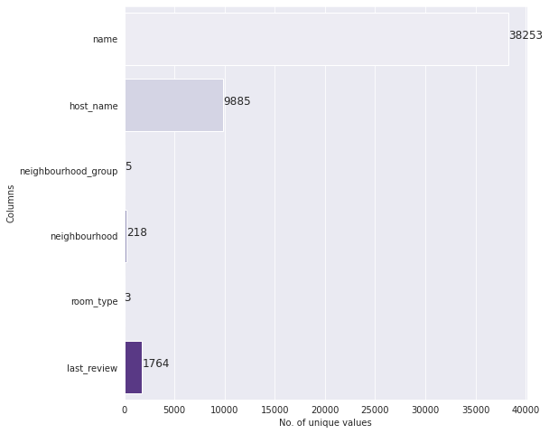

```python
categorical_features = air_bnb.select_dtypes(include='object')
plot_unique_num(categorical_features)
```

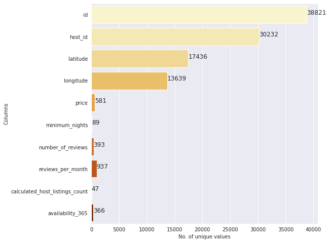

```python
# unique  numerical values
numeric_features = air_bnb.select_dtypes(include=['float', 'integer'])
plot_unique_num(numeric_features)
```

Neighborhood groups and counts of rooms

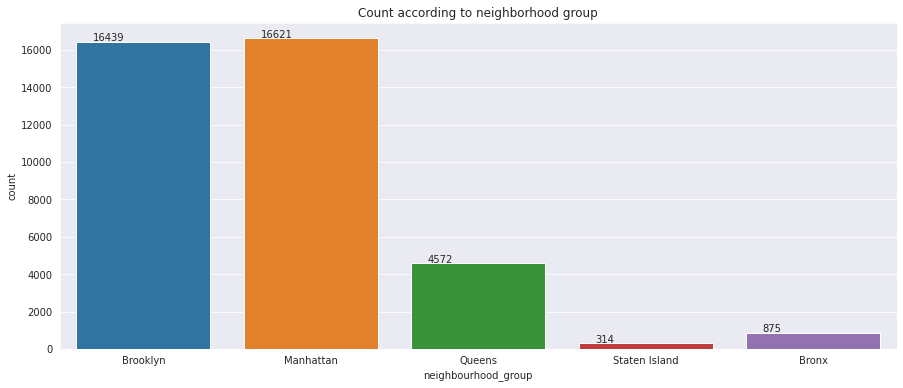

```python
plt.figure(figsize=(15,6))
ax = sns.countplot(x='neighbourhood_group', data=air_bnb)
plt.title('Count according to neighborhood group')

for p in ax.patches:
        ax.annotate('{}'.format(p.get_height()), (p.get_x()+0.1, p.get_height()+50))
```

As the data suggests, most of the rooms in rent are in the Brooklyn/Manhattan area. Fewer rooms are available in the Staten Island than other neighborhood.

#### Price Variation across neighborhood groups according to room type

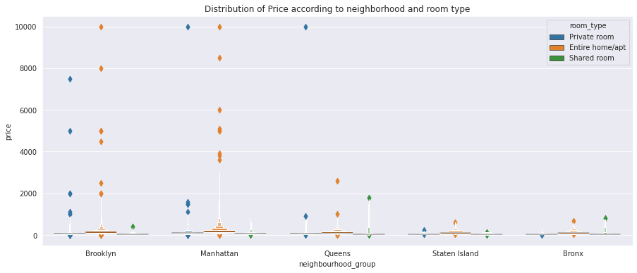

```python
# Between groups and room type
plt.figure(figsize=(15,6))
plt.title('Distribution of Price according to neighborhood and room type')

sns.boxenplot(x='neighbourhood_group', y='price', data=air_bnb, hue='room_type')
```

Since, the most popular Neighbourhood groups are Brooklyn and Manhattan, the prices are also in the high side of the spectrum. We can also infer that the prices are lower in less popular neighbourhood groups.

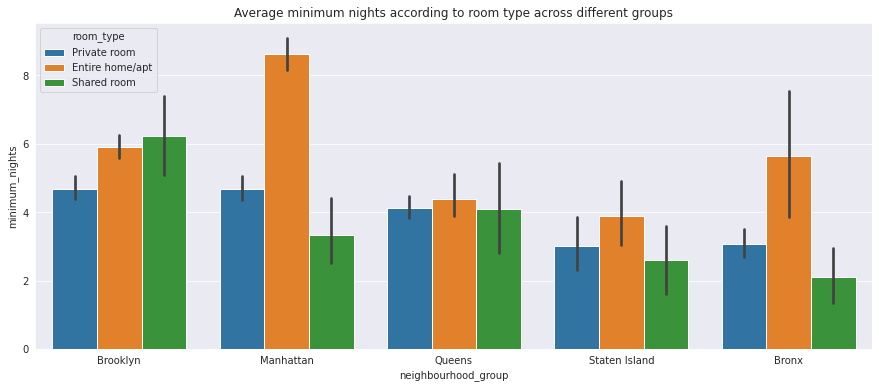

```python
# Average minimum nights according to room type across different groups
plt.figure(figsize=(15,6))
plt.title('Average minimum nights according to room type across different groups')

sns.barplot(x='neighbourhood_group', y='minimum_nights', hue='room_type', data=air_bnb)
```

Across all the Neighbourhood groups, we can see the trend that if you wish to rent an entire home or apartment, you need to rent for an average 4 nights. In manhattan, it goes up to more than 8 nights in average.

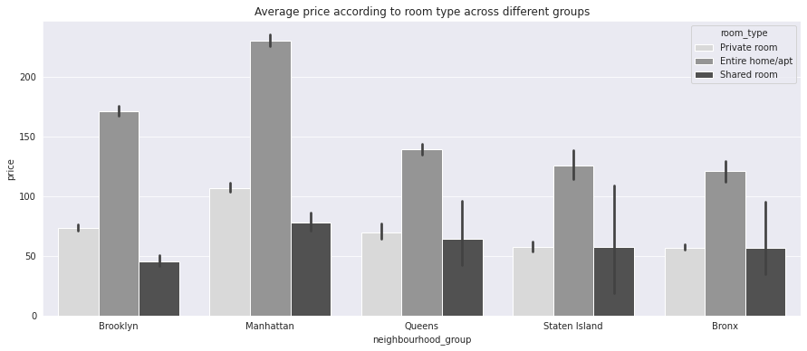

```python
# Average price according to room type across different groups
plt.figure(figsize=(15,6))
plt.title('Average price according to room type across different groups')

sns.barplot(x='neighbourhood_group', y='price', hue='room_type', data=air_bnb, palette='Greys')
```

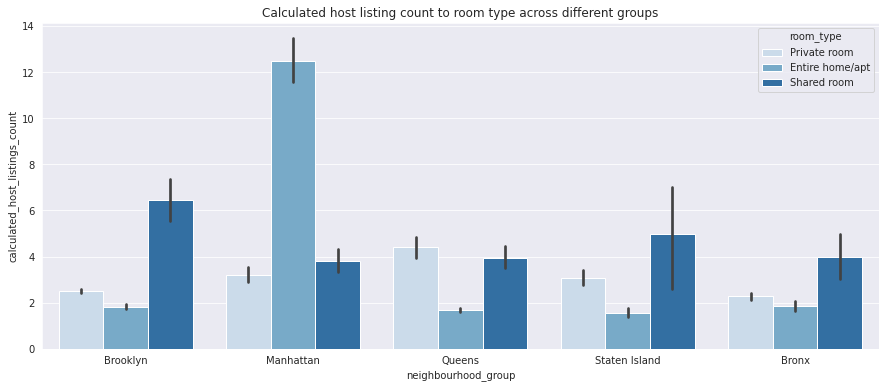

```python
# Calculated host listing count to room type across different groups
plt.figure(figsize=(15,6))
plt.title('Calculated host listing count to room type across different groups')

sns.barplot(x='neighbourhood_group', y='calculated_host_listings_count',
            hue='room_type', data=air_bnb, palette='Blues')
```

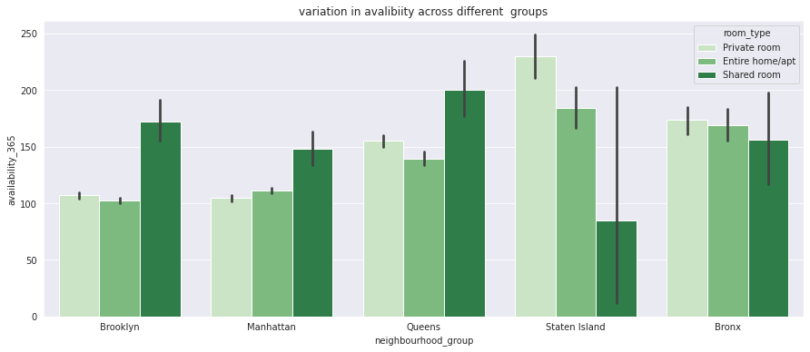

```python
# variation in avalibiity across different  groups
plt.figure(figsize=(15,6))
plt.title('variation in avalibiity across different  groups')

sns.barplot(x='neighbourhood_group', y='availability_365',
            hue='room_type', data=air_bnb, palette='Greens')
```

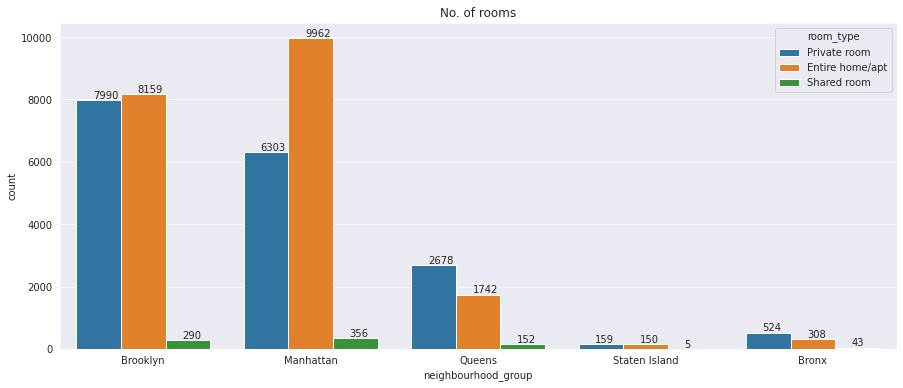

```python
# No. of rooms in different grouptypes
plt.figure(figsize=(15,6))
plt.title('No. of rooms')

ax = sns.countplot(x='neighbourhood_group', hue='room_type', data=air_bnb)
for p in ax.patches:
        ax.annotate('{}'.format(p.get_height()), (p.get_x()+0.1, p.get_height()+50))
```

Manhattan offers the most number of entire home or apartment options but if you are looking for private rooms, Brooklyn may offer more choices. In Queens, Staten Island and Bronx the numbers are relatively low.

[figure not shown]

```python
# Average number of reviews per month count acc to room_type
plt.figure(figsize=(15,6))
plt.title('Average reviews per month')

sns.barplot(x='neighbourhood_group', y='reviews_per_month', hue='room_type', data=air_bnb)
```

[output not shown]

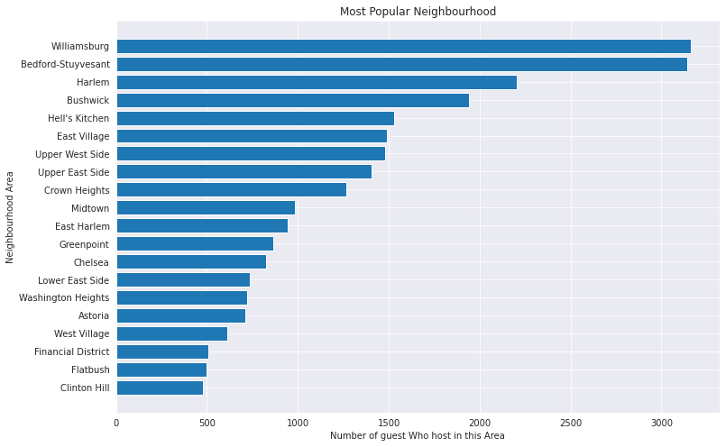

```python
# Most Polpuar Neighbourhood
data = air_bnb.neighbourhood.value_counts()[:20]
plt.figure(figsize=(12, 8))
x = list(data.index)
y = list(data.values)
x.reverse()
y.reverse()

plt.title("Most Popular Neighbourhood")
plt.ylabel("Neighbourhood Area")
plt.xlabel("Number of guest Who host in this Area")

plt.barh(x, y)
```

#### I've heard there are some free houses/rooms, let's find out

```python
print(f"Average of price per night : ${air_bnb.price.mean():.2f}")
print(f"Maximum price per night : ${air_bnb.price.max()}")
print(f"Minimum price per night : ${air_bnb.price.min()}")
```

```
Average of price per night : $142.33
Maximum price per night : $10000
Minimum price per night : $0
```

So, there are some free houses!! hmmmm....

```python
free = air_bnb[air_bnb['price'] == 0]
```

Let's visualize the free houses data

```python
free.shape
```

```
(10, 16)
```

There are only 10 free houses. Let's see which neighbourhood group they come from.

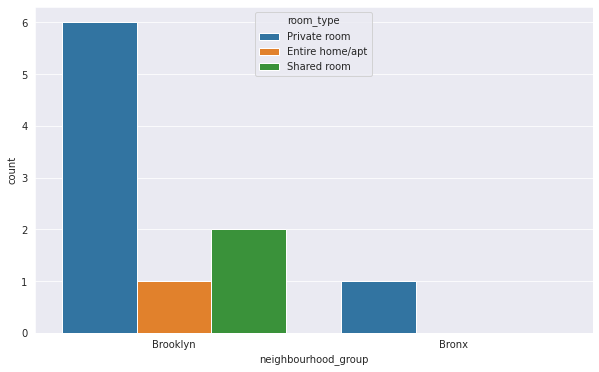

```python
plt.figure(figsize=(10, 6))
sns.countplot(x='neighbourhood_group', hue='room_type', data=free)
```

Which particular neighbourhood do they belong to???

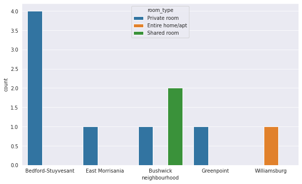

```python
plt.figure(figsize=(10, 6))
sns.countplot(x='neighbourhood', hue='room_type', data=free)
```

# Correlation matrix

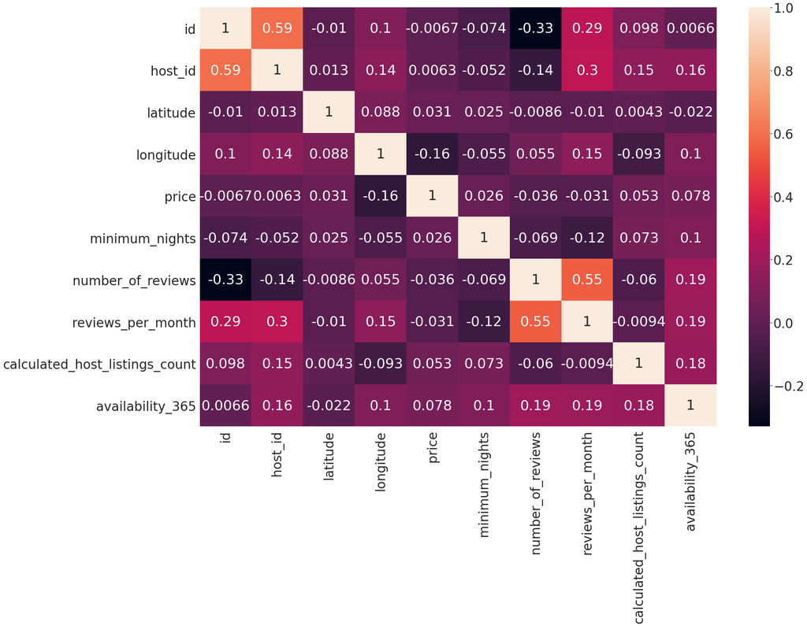

```python
sns.set(font_scale=3)
plt.figure(figsize=(30, 20))
sns.heatmap(air_bnb.corr(), annot=True)
```

# Thanks for checking out.

There is no model building or feature engineering involved because the sole purpose of this notebook is to perform exploratory data analysis and visualize and analyze the data.